# Kaggle Titanic dataset

#### dataset : https://www.kaggle.com/c/titanic

##### tutorial : https://www.dataquest.io/blog/kaggle-fundamentals/

Benedict Aryo (3 Mar 2018)

Latihan mengklasifikasikan apakah penumpang selamat (Survived) atau tidak

```python
import pandas as pd
import numpy as np
import matplotlib.pyplot as plt
%matplotlib inline
import seaborn as sns
sns.set(style='whitegrid')
from IPython.display import Image
```

## 1. Import the train and test datasets

Explore the train and test dataset dimension

```python
train = pd.read_csv('C:/Users/DELL/OneDrive - inc/Data Science/Self Project/Kaggle_Titanic/train.csv')
test = pd.read_csv('C:/Users/DELL/OneDrive - inc/Data Science/Self Project/Kaggle_Titanic/test.csv')
print("Dimension of train table : ",train.shape)
print("Dimension of test table : ",test.shape)
```

```
Dimension of train table :  (891, 12)
Dimension of test table :  (418, 11)
```

## 2. Exploring the data

### Data dictionary

[figure not shown]

### Variable Notes

[figure not shown]

```python
train.head()
```

|  | PassengerId | Survived | Pclass | Name | Sex | Age | SibSp | Parch | Ticket | Fare | Cabin | Embarked |
| --- | --- | --- | --- | --- | --- | --- | --- | --- | --- | --- | --- | --- |
| 0 | 1 | 0 | 3 | Braund, Mr. Owen Harris | male | 22.0 | 1 | 0 | A/5 21171 | 7.2500 | NaN | S |
| 1 | 2 | 1 | 1 | Cumings, Mrs. John Bradley (Florence Briggs Th... | female | 38.0 | 1 | 0 | PC 17599 | 71.2833 | C85 | C |
| 2 | 3 | 1 | 3 | Heikkinen, Miss. Laina | female | 26.0 | 0 | 0 | STON/O2. 3101282 | 7.9250 | NaN | S |
| 3 | 4 | 1 | 1 | Futrelle, Mrs. Jacques Heath (Lily May Peel) | female | 35.0 | 1 | 0 | 113803 | 53.1000 | C123 | S |
| 4 | 5 | 0 | 3 | Allen, Mr. William Henry | male | 35.0 | 0 | 0 | 373450 | 8.0500 | NaN | S |

```
        Survived
Sex
female  0.742038
male    0.188908
```

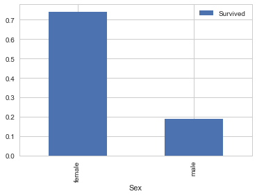

```python
sex_pivot = train.pivot_table(index="Sex",values="Survived")
sex_pivot.plot.bar();
print(sex_pivot)
```

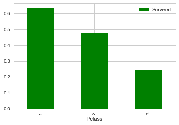

```python
clas_pivot = train.pivot_table(index="Pclass",values="Survived")
clas_pivot.plot.bar(color='green');
```

## 3. Explore and converting age column

eksplorasi categorical features seperti "Sex" dan "Pclass"

```python
train["Age"].describe()
```

```
count    714.000000
mean      29.699118
std       14.526497
min        0.420000
25%       20.125000
50%       28.000000
75%       38.000000
max       80.000000
Name: Age, dtype: float64
```

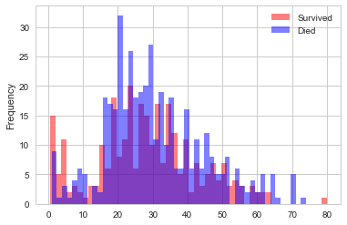

```python
survived = train[train["Survived"]==1]
died = train[train["Survived"]==0]
survived["Age"].plot.hist(alpha=0.5,color='red',bins=50)
died["Age"].plot.hist(alpha=0.5,color='blue',bins=50)
plt.legend(['Survived','Died']);
```

## 4. Separate continous feature into a categorical feature

The diagram below shows how the function converts the data :

[figure not shown]

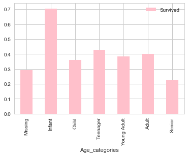

```python
def process_age(df,cut_points,label_names):
    df["Age"] = df["Age"].fillna(-0.5)
    df["Age_categories"] = pd.cut(df["Age"],cut_points,labels = label_names)
    return df

cut_points = [-1,0,5,12,18,35,60,100]
label_names = ["Missing", "Infant", "Child", "Teenager", "Young Adult", "Adult", "Senior"]

train = process_age(train, cut_points, label_names)
test = process_age(test, cut_points, label_names)

pivot = train.pivot_table(index="Age_categories", values='Survived')
pivot.plot.bar(color='pink');
```

## 5. Preparing data for Machine Learning

features columns that useful for predicting survival :

- **Sex**
- **Pclass**
- **Age**, atau setelah pengkategorian menjadi **Age_categories**

```python
print("Pclass value counts : ");
train["Pclass"].value_counts()
```

```
Pclass value counts :
```

```
3    491
1    216
2    184
Name: Pclass, dtype: int64
```

### Create dummy column

create dummy columns for the Pclass features

[figure not shown]

```python
def create_dummies(df, column_name):
    dummies = pd.get_dummies(df[column_name],prefix=column_name)
    df = pd.concat([df,dummies],axis=1)
    return df

for column in ["Pclass","Sex","Age_categories"]:
    train = create_dummies(train,column)
    test = create_dummies(test,column)
```

## Create Machine Learning Model

the model wil be using **Logistic Regression** to perform classification using *Scikit Learn* library with these workflow :

- Instantiate the specific machine learning model
- FIt the model to the training data
- Use the model to make predictions
- Evaluate the accuracy of the predictions

```python
#Import sckit-learn library
from sklearn.linear_model import LogisticRegression
lr = LogisticRegression()

columns = ['Pclass_1', 'Pclass_2', 'Pclass_3', 'Sex_female', 'Sex_male',
       'Age_categories_Missing', 'Age_categories_Infant',
       'Age_categories_Child', 'Age_categories_Teenager',
       'Age_categories_Young Adult', 'Age_categories_Adult',
       'Age_categories_Senior']

lr.fit(train[columns], train['Survived'])
```

```
LogisticRegression(C=1.0, class_weight=None, dual=False, fit_intercept=True,
          intercept_scaling=1, max_iter=100, multi_class='ovr', n_jobs=1,
          penalty='l2', random_state=None, solver='liblinear', tol=0.0001,
          verbose=0, warm_start=False)
```

## Split train data

[figure not shown]

```python
holdout = test
#from now refer to this dataframe as the holdout data

from sklearn.model_selection import train_test_split

all_x = train[columns]
all_y = train['Survived']

train_x,test_x,train_y,test_y = train_test_split(all_x,all_y,test_size = 0.20,random_state=0)
```

```python
lr.fit(train_x,train_y)
predictions = lr.predict(test_x)
```

```python
from sklearn.metrics import accuracy_score
accuracy = accuracy_score(test_y,predictions)
```

```python
print("Accuracy : ",accuracy*100,"%")
```

```
Accuracy :  81.0055865922 %
```

## Using cross validation for more accurate error measurement

to give us a better understanding of the real performance of our model, we can use a technique called *cross validation* to train an test our model on different splits of our data, and then average the accuracy scores.

[figure not shown]

The most common form of cross validation is called **k-fold** cross validation. *Fold* refers to each different iteration that we train our model on, and 'k' just refers to the number of folds. In the diagram above, we have just illustrated k-fold validation where **k** is 5.

```python
from sklearn.model_selection import cross_val_score

scores = cross_val_score(lr, all_x, all_y, cv=10)
scores.sort()
accuracy = scores.mean()
print(scores)
print("K-Fold accuracy : ",accuracy)
```

```
[ 0.76404494  0.76404494  0.7752809   0.78651685  0.8         0.80681818
  0.80898876  0.81111111  0.83146067  0.87640449]
K-Fold accuracy :  0.802467086596
```

## Making predictions on Unseen Data

```python
lr.fit(all_x,all_y)
holdout_predictions = lr.predict(holdout[columns])
```

## Creating a Submission File

Based on Kagle instruction :

*You should submit a csv file with exactly 418 entries plus a header row. Your submission will show an error if you have extra columns (beyond PassengerId and Survived) or rows.*

*The file should have exactly 2 columns:*

- *PassengerId (sorted in any order)*
- *Survived (contains your binary predictions: 1 for survived, 0 for deceased)*

```python
holdout_ids = holdout["PassengerId"]
submission_df ={"PassengerId" : holdout_ids,
               "Survived": holdout_predictions}
submission = pd.DataFrame(submission_df)
submission.to_csv("submission.csv",index=False)
```